# Polluting Industries and Agricultural Productivity: Evidence from Mining in Ghana

Aragon, and Rud

APEC 8990

Paper Presentations

September 17, 2024

## Motivation

- In rural communities, often there is a tradeoff between working in agriculture or other capital-intensive industries
- In Ghana, gold mining near farms may change the agricultural production function of local farmers – espically considering externalities
- There is a non-input externality of mining on traditional sectors
- The expansion of mines can be costly to farming communities

## Research Question

> What is the impact of polluting industries – such as gold mining – on agricultural productivity for traditional farming?

[figure not shown]

## Overview

- Context: Ghana 1997 - 2005
  - Expansion of large-scale, modern mining (97% of mines) located on fertile agricultural lands
  - Extractive industry with pollution externality and draws from local labor force
- Methods:
  - Difference in Differences: Compare mining and non-mining areas by distance and change in mining
  - Instrumental Variable: Identify production function using farmers’ input endowments
- Findings near mines:
  - $\downarrow$ agricultural output and total factor productivity
  - $\uparrow$ poverty rates & $\uparrow$ pollution of $NO_2$

## Data

### Gold Production

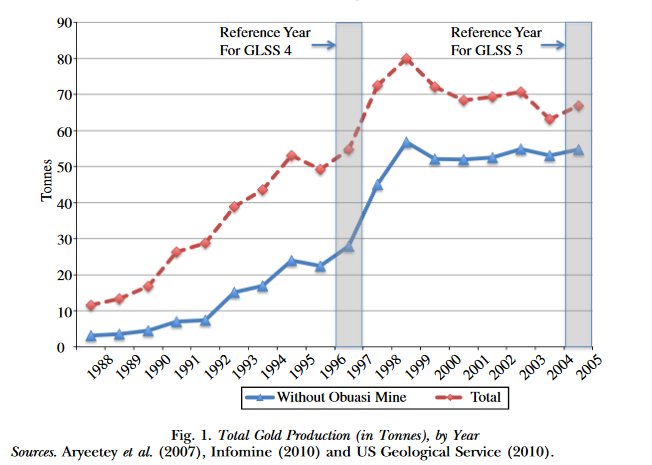

## Data

### Ghana 1997 - 2005

1. Ghana Living Standards Survey (GLSS 4 & 5)
   - 1998 - 2006
   - 1,627 farmers
2. Gold Mines in Western, Ashanti, & Central regions
   - ArcGIS map of gold mines
   - Unclear where this is sourced (Ghana’s EPA…)
3. Relative Average Troposheric $NO_2$ Pollution
   - NASA’s Ozone Monitoring Instrument (OMI)
   - Apirl - June 2005

## Data

### Study Area

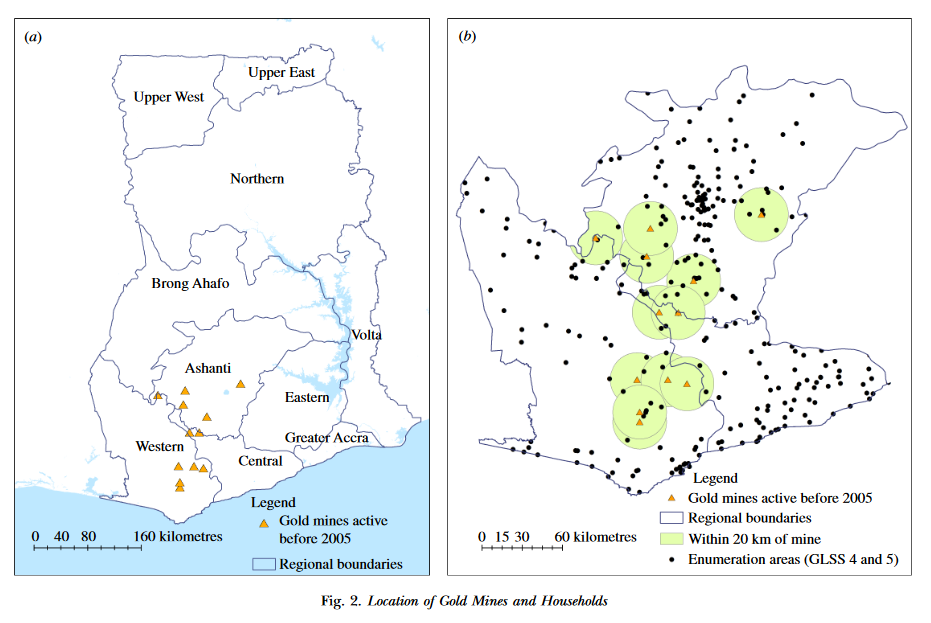

## Empirical Strategy

### Agricultural Production Function

Consumer-producer household framework (Benjamin, 1992; Bardhan and Urdy, 1999) $\to$ Agricultural production function

- $\eta_i$: Imperfect input markets (heterogenous access to input markets)
- $S_{vt}$: Mining activities

$$\begin{align}
Y_{ivt} = & A_{ivt} M_{it}^\alpha L_{it}^\beta e^{\varepsilon_{it}} \\
A_{ivt} = & exp(\eta_i + \rho_v + \gamma S_{vt})
\end{align}$$

Identify with farmers’ input endownments as IV: land holdings, household size, etc.

## Empirical Strategy

### Difference in Differences

Sources of Variation:

- $\theta$: Distance from household to nearest mine
- $\gamma$ Changes in mining production

$$Y_{ivdt} = \alpha m_{it} + \beta l_{it} + \gamma S_{vt} + \phi Z_i + \delta_d + \psi_t + \theta mining_v + \xi_{ivt}$$

## Results

### Agricultural Productivity

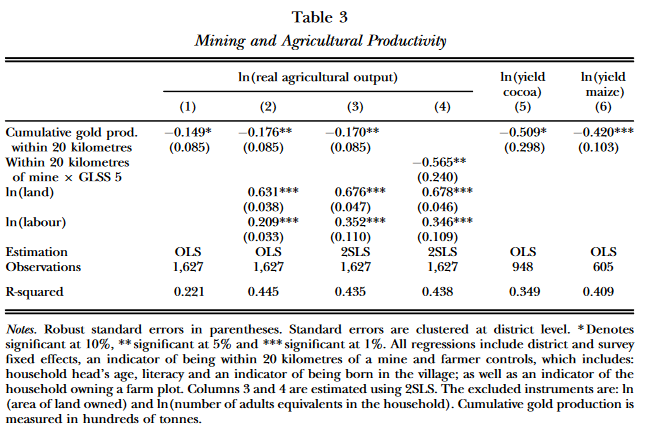

## Results

### Pollution

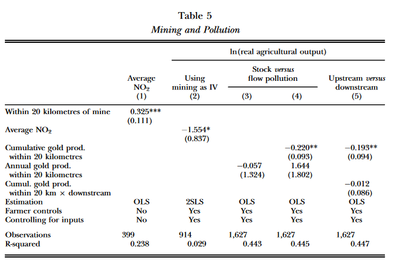

## Results

### Poverty

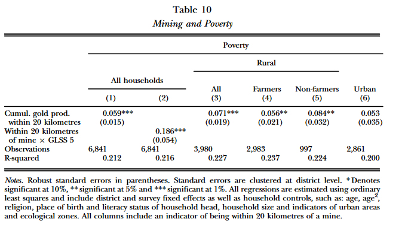

## Summary

- Mining Areas lead to 40% reduction in total factor productivity
- Increase in rural poverty
- Call for environmental assessments to consider impact on agricultural and farmers’ incomes
- Mining revenues ($75 million) do not exceed loss in farmer incomes ($97 million)
- Limitation: Only applicable to Ghana context